# Project: Identify Customer Segments

In this project, you will apply unsupervised learning techniques to identify segments of the population that form the core customer base for a mail-order sales company in Germany. These segments can then be used to direct marketing campaigns towards audiences that will have the highest expected rate of returns. The data that you will use has been provided by our partners at Bertelsmann Arvato Analytics, and represents a real-life data science task.

This notebook will help you complete this task by providing a framework within which you will perform your analysis steps. In each step of the project, you will see some text describing the subtask that you will perform, followed by one or more code cells for you to complete your work. **Feel free to add additional code and markdown cells as you go along so that you can explore everything in precise chunks.** The code cells provided in the base template will outline only the major tasks, and will usually not be enough to cover all of the minor tasks that comprise it.

It should be noted that while there will be precise guidelines on how you should handle certain tasks in the project, there will also be places where an exact specification is not provided. **There will be times in the project where you will need to make and justify your own decisions on how to treat the data.** These are places where there may not be only one way to handle the data. In real-life tasks, there may be many valid ways to approach an analysis task. One of the most important things you can do is clearly document your approach so that other scientists can understand the decisions you've made.

At the end of most sections, there will be a Markdown cell labeled **Discussion**. In these cells, you will report your findings for the completed section, as well as document the decisions that you made in your approach to each subtask. **Your project will be evaluated not just on the code used to complete the tasks outlined, but also your communication about your observations and conclusions at each stage.**

```python
# import libraries here; add more as necessary
import numpy as np
import pandas as pd
import matplotlib.pyplot as plt
import seaborn as sns

# magic word for producing visualizations in notebook
%matplotlib inline

'''
Import note: The classroom currently uses sklearn version 0.19.
If you need to use an imputer, it is available in sklearn.preprocessing.Imputer,
instead of sklearn.impute as in newer versions of sklearn.
'''
```

```
'\nImport note: The classroom currently uses sklearn version 0.19.\nIf you need to use an imputer, it is available in sklearn.preprocessing.Imputer,\ninstead of sklearn.impute as in newer versions of sklearn.\n'
```

### Step 0: Load the Data

Each row of the demographics files represents:

- a single person,
- but also includes information outside of individuals, including information about their household, building, and neighborhood.
1. You will use this information to cluster the general population into groups with similar demographic properties.
2. Then, you will see how the people in the customers dataset fit into those created clusters. The hope here is that certain clusters are over-represented in the customers data, as compared to the general population; those over-represented clusters will be assumed to be part of the core userbase. This information can then be used for further applications, such as targeting for a marketing campaign.

To start off with, load in the demographics data for the general population into a pandas DataFrame, and do the same for the feature attributes summary. Note for all of the `.csv` data files in this project: they're semicolon (`;`) delimited, so you'll need an additional argument in your [`read_csv()`](https://pandas.pydata.org/pandas-docs/stable/generated/pandas.read_csv.html) call to read in the data properly. Also, considering the size of the main dataset, it may take some time for it to load completely.

Once the dataset is loaded, it's recommended that you take a little bit of time just browsing the general structure of the dataset and feature summary file. You'll be getting deep into the innards of the cleaning in the first major step of the project, so gaining some general familiarity can help you get your bearings.

```python
# Load in the general demographics data.
azdias = pd.read_csv('Udacity_AZDIAS_Subset.csv', sep=';')

# Load in the feature summary file.
feat_info = pd.read_csv('AZDIAS_Feature_Summary.csv', sep=';')

# Load in my cleaned version of Data_Dictionary translation to csv file
feat_trans = pd.read_csv('features_summ.csv', sep=';', header=None)
feat_trans.columns = ['attribute', 'attribute_trans']
```

```python
# To incorporate translated features to `feat_info` column
feat_info = feat_info.merge(feat_trans, on='attribute', how='left')
```

### Inspection of datasets

```python
# Check the structure of the data after it's loaded (e.g. print the number of
# rows and columns, print the first few rows).
print(f'Azdiaz dataset - rows {azdias.shape[0]}, columns {azdias.shape[1]}')
print(f'Feature info - rows {feat_info.shape[0]}, columns {feat_info.shape[1]}')
print(f'My feature translation - rows {feat_trans.shape[0]}, columns {feat_trans.shape[1]}')
```

```
Azdiaz dataset - rows 891221, columns 85
Feature info - rows 85, columns 5
My feature translation - rows 85, columns 2
```

```python
# AZDIAS dataset
azdias.head()
```

|  | AGER_TYP | ALTERSKATEGORIE_GROB | ANREDE_KZ | CJT_GESAMTTYP | FINANZ_MINIMALIST | FINANZ_SPARER | FINANZ_VORSORGER | FINANZ_ANLEGER | FINANZ_UNAUFFAELLIGER | FINANZ_HAUSBAUER | ... | PLZ8_ANTG1 | PLZ8_ANTG2 | PLZ8_ANTG3 | PLZ8_ANTG4 | PLZ8_BAUMAX | PLZ8_HHZ | PLZ8_GBZ | ARBEIT | ORTSGR_KLS9 | RELAT_AB |
| --- | --- | --- | --- | --- | --- | --- | --- | --- | --- | --- | --- | --- | --- | --- | --- | --- | --- | --- | --- | --- | --- |
| 0 | -1 | 2 | 1 | 2.0 | 3 | 4 | 3 | 5 | 5 | 3 | ... | NaN | NaN | NaN | NaN | NaN | NaN | NaN | NaN | NaN | NaN |
| 1 | -1 | 1 | 2 | 5.0 | 1 | 5 | 2 | 5 | 4 | 5 | ... | 2.0 | 3.0 | 2.0 | 1.0 | 1.0 | 5.0 | 4.0 | 3.0 | 5.0 | 4.0 |
| 2 | -1 | 3 | 2 | 3.0 | 1 | 4 | 1 | 2 | 3 | 5 | ... | 3.0 | 3.0 | 1.0 | 0.0 | 1.0 | 4.0 | 4.0 | 3.0 | 5.0 | 2.0 |
| 3 | 2 | 4 | 2 | 2.0 | 4 | 2 | 5 | 2 | 1 | 2 | ... | 2.0 | 2.0 | 2.0 | 0.0 | 1.0 | 3.0 | 4.0 | 2.0 | 3.0 | 3.0 |
| 4 | -1 | 3 | 1 | 5.0 | 4 | 3 | 4 | 1 | 3 | 2 | ... | 2.0 | 4.0 | 2.0 | 1.0 | 2.0 | 3.0 | 3.0 | 4.0 | 6.0 | 5.0 |

5 rows × 85 columns

```python
azdias.describe()
```

|  | AGER_TYP | ALTERSKATEGORIE_GROB | ANREDE_KZ | CJT_GESAMTTYP | FINANZ_MINIMALIST | FINANZ_SPARER | FINANZ_VORSORGER | FINANZ_ANLEGER | FINANZ_UNAUFFAELLIGER | FINANZ_HAUSBAUER | ... | PLZ8_ANTG1 | PLZ8_ANTG2 | PLZ8_ANTG3 | PLZ8_ANTG4 | PLZ8_BAUMAX | PLZ8_HHZ | PLZ8_GBZ | ARBEIT | ORTSGR_KLS9 | RELAT_AB |
| --- | --- | --- | --- | --- | --- | --- | --- | --- | --- | --- | --- | --- | --- | --- | --- | --- | --- | --- | --- | --- | --- |
| count | 891221.000000 | 891221.000000 | 891221.000000 | 886367.000000 | 891221.000000 | 891221.000000 | 891221.000000 | 891221.000000 | 891221.000000 | 891221.000000 | ... | 774706.000000 | 774706.000000 | 774706.000000 | 774706.000000 | 774706.000000 | 774706.000000 | 774706.000000 | 794005.000000 | 794005.000000 | 794005.00000 |
| mean | -0.358435 | 2.777398 | 1.522098 | 3.632838 | 3.074528 | 2.821039 | 3.401106 | 3.033328 | 2.874167 | 3.075121 | ... | 2.253330 | 2.801858 | 1.595426 | 0.699166 | 1.943913 | 3.612821 | 3.381087 | 3.167854 | 5.293002 | 3.07222 |
| std | 1.198724 | 1.068775 | 0.499512 | 1.595021 | 1.321055 | 1.464749 | 1.322134 | 1.529603 | 1.486731 | 1.353248 | ... | 0.972008 | 0.920309 | 0.986736 | 0.727137 | 1.459654 | 0.973967 | 1.111598 | 1.002376 | 2.303739 | 1.36298 |
| min | -1.000000 | 1.000000 | 1.000000 | 1.000000 | 1.000000 | 1.000000 | 1.000000 | 1.000000 | 1.000000 | 1.000000 | ... | 0.000000 | 0.000000 | 0.000000 | 0.000000 | 1.000000 | 1.000000 | 1.000000 | 1.000000 | 0.000000 | 1.00000 |
| 25% | -1.000000 | 2.000000 | 1.000000 | 2.000000 | 2.000000 | 1.000000 | 3.000000 | 2.000000 | 2.000000 | 2.000000 | ... | 1.000000 | 2.000000 | 1.000000 | 0.000000 | 1.000000 | 3.000000 | 3.000000 | 3.000000 | 4.000000 | 2.00000 |
| 50% | -1.000000 | 3.000000 | 2.000000 | 4.000000 | 3.000000 | 3.000000 | 3.000000 | 3.000000 | 3.000000 | 3.000000 | ... | 2.000000 | 3.000000 | 2.000000 | 1.000000 | 1.000000 | 4.000000 | 3.000000 | 3.000000 | 5.000000 | 3.00000 |
| 75% | -1.000000 | 4.000000 | 2.000000 | 5.000000 | 4.000000 | 4.000000 | 5.000000 | 5.000000 | 4.000000 | 4.000000 | ... | 3.000000 | 3.000000 | 2.000000 | 1.000000 | 3.000000 | 4.000000 | 4.000000 | 4.000000 | 7.000000 | 4.00000 |
| max | 3.000000 | 9.000000 | 2.000000 | 6.000000 | 5.000000 | 5.000000 | 5.000000 | 5.000000 | 5.000000 | 5.000000 | ... | 4.000000 | 4.000000 | 3.000000 | 2.000000 | 5.000000 | 5.000000 | 5.000000 | 9.000000 | 9.000000 | 9.00000 |

8 rows × 81 columns

```python
# Feature info
feat_info.head()
```

|  | attribute | information_level | type | missing_or_unknown | attribute_trans |
| --- | --- | --- | --- | --- | --- |
| 0 | AGER_TYP | person | categorical | [-1,0] | Best-ager typology |
| 1 | ALTERSKATEGORIE_GROB | person | ordinal | [-1,0,9] | Estimated age based on given name analysis |
| 2 | ANREDE_KZ | person | categorical | [-1,0] | Gender |
| 3 | CJT_GESAMTTYP | person | categorical | [0] | Customer-Journey-Typology: preferred informati... |
| 4 | FINANZ_MINIMALIST | person | ordinal | [-1] | low financial interest |

### Dataset features

- Based on the spread of our data, the `person` feature group covers over 50% of the dataset

#### Summary of specific dataset feature groupings

The dataset labels aren't very readable by first glance, going through the 85 features, here is a summary by groupings

1. **Person** - age/DOB , gender, purchasing information sources & habits, vacation habits, personal financial standing, health status, detailed and higher level life stage/family information, social status, academic background, nationality, politics
2. **Household** - Age of household and length of residence, people in household, household income
3. **Building** - Type of building, households in building, location of building (East / West germany), neighborhood quality
4. **RR4 microcell** - lifestage information of microcell
5. **RR3 microcell** - buildings in microcell, households in microcell
6. **Macrocell** - buildings in macrocell, households in macrocell
7. **Postcode** - distance to urban center, distance to city center, density of households
8. **Region** - neighborhood type (e.g. upper/middle class etc), purchasing power, online affinity
9. **Community** - unemployment data and size of community

From the summary above, majority of the data are **factual** data which is always beneficial for data modelling. One non-factual data found is `W_KEIT_KIND_HH - Likelihood of children in household`.

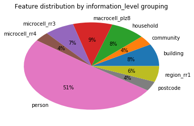

```python
features = feat_info.groupby('information_level').count()
attribute_count = features['attribute']
feature_names = features.index

plt.title('Feature distribution by information_level grouping')
plt.pie(attribute_count, labels=feature_names, autopct='%.0f%%')
plt.show()
```

#### Data types

- Only `8%` of our data is numeric, while the remainder are categorical (in the sense that they are quantitative variables, not to be confused with the categorical labelling for 1 data type below), and a single time-series data.

Numeric data

- Most of numerical features make sense
- Considerations would be to update the following to datetime features:
  1. `GEBURTSJAHR` - Year of birth
  2. `MIN_GEBAEUDEJAHR` - First year building was mentioned in the database

Timeseries/Datetime data

- The only timeseries, `ALTER_HH` - birthdate of head of household is appropriate to be datetime

Categorical

- From now onwards, we would be using the terms `nominal` and `ordinal` to describe the 2 types of categorical variables. Nominal categories do not have an intrinsic ordering. E.g. Primary 2 genders would be male and female. Ordinal categories would have an ordering towards them. E.g. would be the `REGIOTYP` feature (describing neighborhood typology) where a *1* score would relate to individuals in upper-class while a lower score of *4* is middle-class and *7* is marginal groups.
  - **Ordinal** - Inspection of ordinal variables below suggest that they are appropriate
  - **Nominal** - Similarly, inspection of them suggest that they are appropriate
- There is also an additional category `mixed` where it contains a mix of ordinal and nominal labellings. Take `PLZ8_BAUMAX` for example (describing most common building type in region), there is ordinal quality where numbers *1 to 4* is a scale of number of family homes. However, label *5* would be used to describe that the area mainly relates to business buildings.
  - It may be beneficial to create a new feature set to segregate these mixed variables, e.g. for the case above we could have another feature column containing boolean on whether the area primarily has to residential or business buildings.
  - However, not all features in the `Mixed` columns are this straightforward

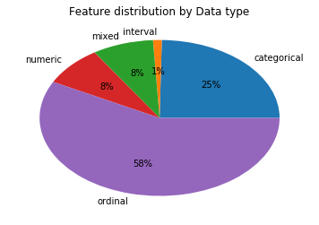

```python
features = feat_info.groupby('type').count()
type_count = features['attribute']
feature_names = features.index

plt.title('Feature distribution by Data type')
plt.pie(type_count, labels=feature_names, autopct='%.0f%%')
plt.show()
```

```python
def filter_type(data_type):
    return feat_info[feat_info['type'] == data_type]
```

```python
# Review of numeric data
filter_type('numeric')
```

|  | attribute | information_level | type | missing_or_unknown | attribute_trans |
| --- | --- | --- | --- | --- | --- |
| 11 | GEBURTSJAHR | person | numeric | [0] | Year of birth |
| 44 | ANZ_PERSONEN | household | numeric | [] | Number of adults in household |
| 45 | ANZ_TITEL | household | numeric | [] | Number of professional academic title holders ... |
| 50 | ANZ_HAUSHALTE_AKTIV | building | numeric | [0] | Number of households in the building |
| 51 | ANZ_HH_TITEL | building | numeric | [] | Number of professional academic title holders ... |
| 54 | MIN_GEBAEUDEJAHR | building | numeric | [0] | First year building was mentioned in the database |
| 74 | KBA13_ANZAHL_PKW | macrocell_plz8 | numeric | [] | Number of cars in the PLZ8 region |

```python
# Review of interval data
filter_type('interval')
```

|  | attribute | information_level | type | missing_or_unknown | attribute_trans |
| --- | --- | --- | --- | --- | --- |
| 43 | ALTER_HH | household | interval | [0] | Birthdate of head of household |

```python
# Review of Ordinal data
filter_type('ordinal').head()
```

|  | attribute | information_level | type | missing_or_unknown | attribute_trans |
| --- | --- | --- | --- | --- | --- |
| 1 | ALTERSKATEGORIE_GROB | person | ordinal | [-1,0,9] | Estimated age based on given name analysis |
| 4 | FINANZ_MINIMALIST | person | ordinal | [-1] | low financial interest |
| 5 | FINANZ_SPARER | person | ordinal | [-1] | Financial typology - money-saver |
| 6 | FINANZ_VORSORGER | person | ordinal | [-1] | Financial typology - be prepared |
| 7 | FINANZ_ANLEGER | person | ordinal | [-1] | Financial typology - investor |

```python
# Review of Categorical data
filter_type('categorical').head()
```

|  | attribute | information_level | type | missing_or_unknown | attribute_trans |
| --- | --- | --- | --- | --- | --- |
| 0 | AGER_TYP | person | categorical | [-1,0] | Best-ager typology |
| 2 | ANREDE_KZ | person | categorical | [-1,0] | Gender |
| 3 | CJT_GESAMTTYP | person | categorical | [0] | Customer-Journey-Typology: preferred informati... |
| 10 | FINANZTYP | person | categorical | [-1] | Most descriptive financial type for individual |
| 12 | GFK_URLAUBERTYP | person | categorical | [] | Vacation habits |

```python
# Review of Mixed data
filter_type('mixed')
```

|  | attribute | information_level | type | missing_or_unknown | attribute_trans |
| --- | --- | --- | --- | --- | --- |
| 15 | LP_LEBENSPHASE_FEIN | person | mixed | [0] | Life stage, fine scale |
| 16 | LP_LEBENSPHASE_GROB | person | mixed | [0] | Life stage, rough scale |
| 22 | PRAEGENDE_JUGENDJAHRE | person | mixed | [-1,0] | Dominating movement of person's youth (east vs... |
| 56 | WOHNLAGE | building | mixed | [-1] | Neighborhood quality (or rural flag) |
| 59 | CAMEO_INTL_2015 | microcell_rr4 | mixed | [-1,XX] | German CAMEO: Wealth / Life Stage Typology, ma... |
| 64 | KBA05_BAUMAX | microcell_rr3 | mixed | [-1,0] | Most common building type within the microcell |
| 79 | PLZ8_BAUMAX | macrocell_plz8 | mixed | [-1,0] | Most common building type within the PLZ8 region |

> **Tip**: Add additional cells to keep everything in reasonably-sized chunks! Keyboard shortcut `esc --> a` (press escape to enter command mode, then press the 'A' key) adds a new cell before the active cell, and `esc --> b` adds a new cell after the active cell. If you need to convert an active cell to a markdown cell, use `esc --> m` and to convert to a code cell, use `esc --> y`.

## Step 1: Preprocessing

### Step 1.1: Assess Missing Data

The feature summary file contains a summary of properties for each demographics data column. You will use this file to help you make cleaning decisions during this stage of the project. First of all, you should assess the demographics data in terms of missing data. Pay attention to the following points as you perform your analysis, and take notes on what you observe. Make sure that you fill in the **Discussion** cell with your findings and decisions at the end of each step that has one!

#### Step 1.1.1: Convert Missing Value Codes to NaNs

The fourth column of the feature attributes summary (loaded in above as `feat_info`) documents the codes from the data dictionary that indicate missing or unknown data. While the file encodes this as a list (e.g. `[-1,0]`), this will get read in as a string object. You'll need to do a little bit of parsing to make use of it to identify and clean the data. Convert data that matches a 'missing' or 'unknown' value code into a numpy NaN value. You might want to see how much data takes on a 'missing' or 'unknown' code, and how much data is naturally missing, as a point of interest.

**As one more reminder, you are encouraged to add additional cells to break up your analysis into manageable chunks.**

```python
# Identify missing or unknown data values and convert them to NaNs.
# Note: There is an issue with matplotlib where the label axis is alphabetically ordered
# - https://stackoverflow.com/questions/49647875/how-to-prevent-alphabetical-sorting-for-python-bars-with-matplotlib
def get_null(df):
    null = (df.shape[0] - df.describe().loc['count'])
    null.sort_values(ascending=False, inplace=True)
    return null

def plot_null(null, title, w, h):
    plt.figure(figsize=(w, h))
    null.plot.barh()
    plt.xlabel('Number of missing data')
    plt.ylabel('Features')
    plt.title(title)
    plt.show()
```

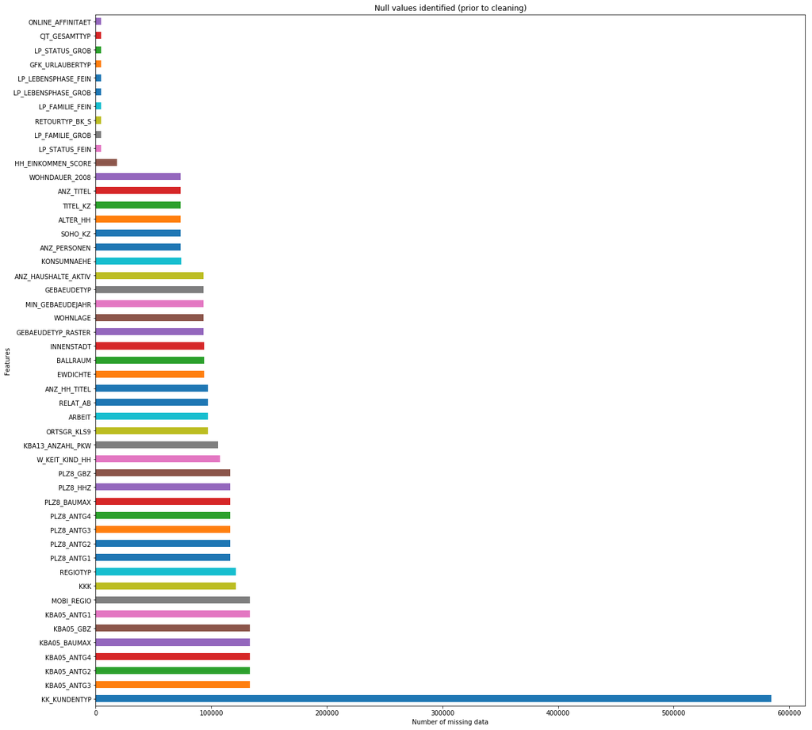

```python
missing_prior = get_null(azdias)
# Only plot features with missing cells > 0
plot_null(missing_prior[missing_prior > 0], 'Null values identified (prior to cleaning)', 20, 20)
```

#### Observation of NULL values prior to removal of null values

- Prior to removal, our dataset has at least `4.5mln` cells of missing data, with majority of it coming from `KK_KUNDENTYP`, **Consumer pattern over past 12 months**
- The majority of our feature set 49/85, contains missing data with an average of `92k` cells

```python
def describe_missing(s):
    print(f'Total missing data prior to cleaning: {sum(s)}')
    print(f'Total features columns with missing data: {sum(s > 0)}')
    print(f'Average missing data for each missing column: {round(sum(s) / sum(s > 0), 2)}')
```

```python
describe_missing(missing_prior)
```

```
Total missing data prior to cleaning: 4506753.0
Total features columns with missing data: 49
Average missing data for each missing column: 91974.55
```

#### Removal of missing values based on list of missing values in `feat_info.csv`

1. First clean up the list data in feat_info to convert to
   - (i) list and
   - (ii) integer (if appropriate), there are some features where unknown values are denoted with an `XX`
2. Create new dataframe after applying filtering to exclude missing unknown values
3. Compare missing unknown values before and after

```python
def make_list(elem):
    # https://stackoverflow.com/questions/23119472/in-pandas-python-reading-array-stored-as-string
    elem = elem[1:-1].split(',')
    # Strip negative sign - https://stackoverflow.com/questions/28279732/how-to-type-negative-number-with-isdigit
    for i in range(len(elem)):
        if elem[i].lstrip('-').isnumeric():
            elem[i] = int(elem[i])
    return elem

missing_unknown = [make_list(x) for x in feat_info['missing_or_unknown']]
```

```python
# Converting string to array
def df_make_na(df):
    new_df = df.copy()
    for att, unknown in zip(feat_info['attribute'], missing_unknown):
        new_df[att] = new_df[att].apply(lambda x : np.nan if x in unknown else x)
    return new_df
```

```python
clean_null_azdias = df_make_na(azdias)
```

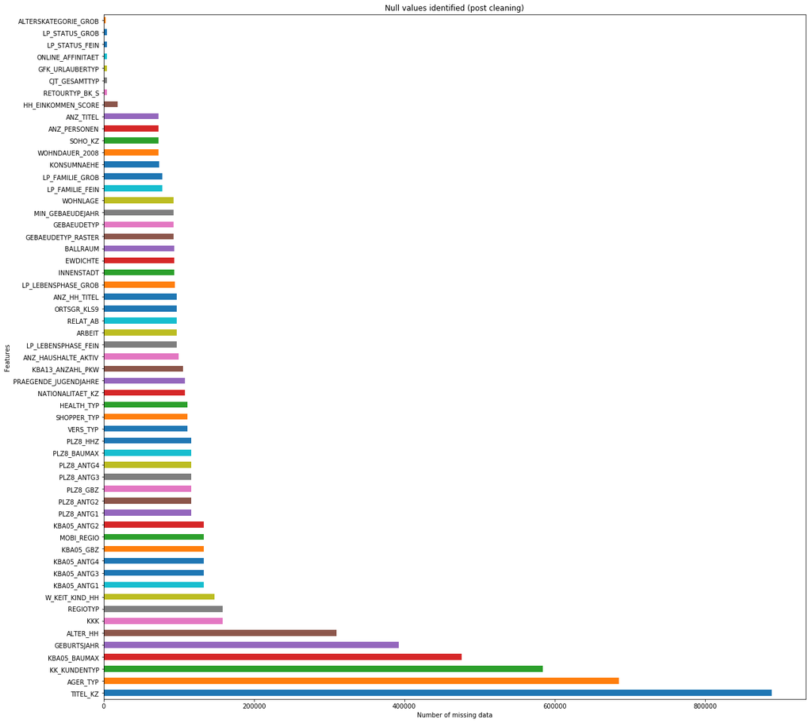

```
Total missing data prior to cleaning: 7982725.0
Total features columns with missing data: 57
Average missing data for each missing column: 140047.81
```

```python
missing_post = get_null(clean_null_azdias)
# Only plot features with missing cells > 0
plot_null(missing_post[missing_post > 0], 'Null values identified (post cleaning)', 20, 20)
describe_missing(missing_post)
```

#### After removing missing unknown values

We will perform more detailed analysis over these missing values in the subsequent cells

```python
'''
Returns list of features when pass in list of types
'''
def get_features(arr):
    # to filter attributes which contain certain datatype
    features = feat_info['type'].apply(lambda x : True if x in arr else False)
    return feat_info[features]['attribute']
```

#### Step 1.1.2: Assess Missing Data in Each Column

How much missing data is present in each column? There are a few columns that are outliers in terms of the proportion of values that are missing. You will want to use matplotlib's [`hist()`](https://matplotlib.org/api/_as_gen/matplotlib.pyplot.hist.html) function to visualize the distribution of missing value counts to find these columns. Identify and document these columns. While some of these columns might have justifications for keeping or re-encoding the data, for this project you should just remove them from the dataframe. (Feel free to make remarks about these outlier columns in the discussion, however!)

For the remaining features, are there any patterns in which columns have, or share, missing data?

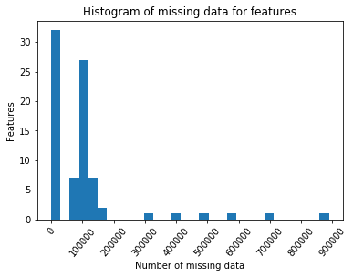

```python
# Perform an assessment of how much missing data there is in each column of the
# dataset.
plt.title('Histogram of missing data for features')
plt.hist(missing_post, bins = 30)
plt.xticks(list(range(0, 1000000, 100000)), rotation=50)
plt.xlabel('Number of missing data')
plt.ylabel('Features')
plt.show()
```

#### Outlier features

- Our histogram plot above suggest that outlier data exists after the `300,000` mark
- We use this as a threshold to separate our outlier data

#### List of outlier features and its description are as follows:

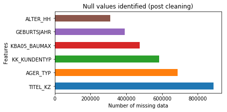

```
Total missing data prior to cleaning: 3338625.0
Total features columns with missing data: 6
Average missing data for each missing column: 556437.5
```

```python
more_300k = missing_post[missing_post > 300000]
plot_null(more_300k, 'Null values identified (post cleaning)', 6, 3)
describe_missing(more_300k)
```

```python
feat_info[feat_info['attribute'].isin(more_300k.index)]
```

|  | attribute | information_level | type | missing_or_unknown | attribute_trans |
| --- | --- | --- | --- | --- | --- |
| 0 | AGER_TYP | person | categorical | [-1,0] | Best-ager typology |
| 11 | GEBURTSJAHR | person | numeric | [0] | Year of birth |
| 40 | TITEL_KZ | person | categorical | [-1,0] | Academic title flag |
| 43 | ALTER_HH | household | interval | [0] | Birthdate of head of household |
| 47 | KK_KUNDENTYP | household | categorical | [-1] | Consumer pattern over past 12 months |
| 64 | KBA05_BAUMAX | microcell_rr3 | mixed | [-1,0] | Most common building type within the microcell |

Although it would make sense to perform further feature engineering over these, due to the magnitude of missing values, and there being only `6` features with significant unknown/missing values. We will be dropping these columns for the scope of this project submission.

```python
# Remove the outlier columns from the dataset. (You'll perform other data
# engineering tasks such as re-encoding and imputation later.)
clean_outlier_azdias = clean_null_azdias.drop(more_300k.index, axis=1)
```

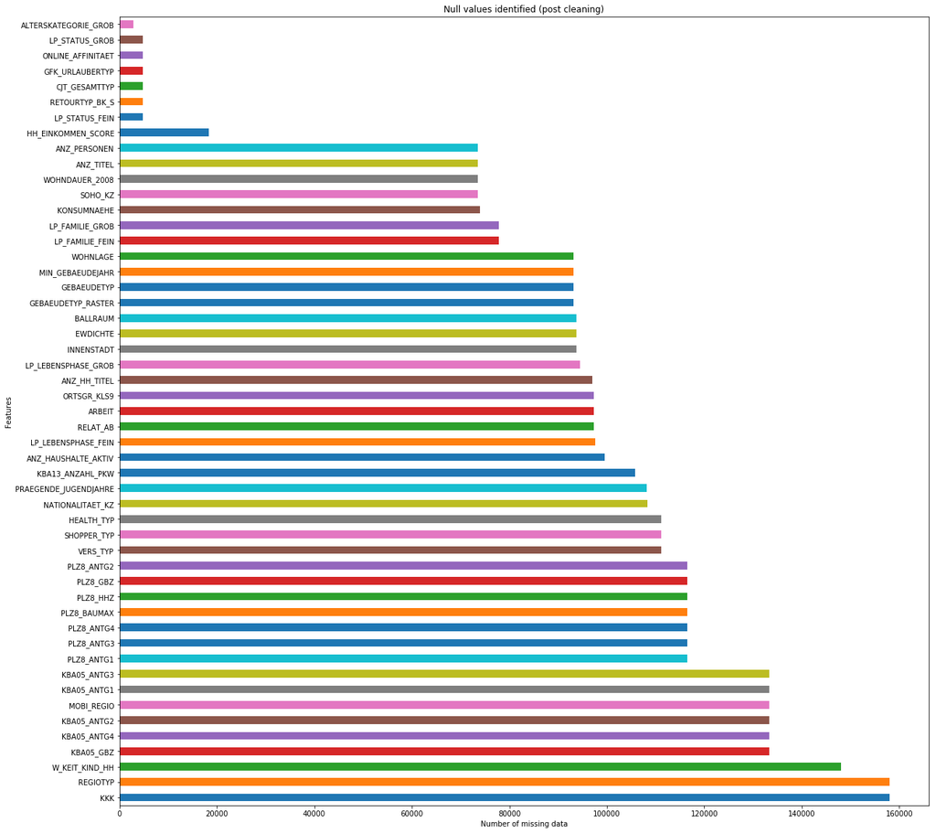

```
Total missing data prior to cleaning: 4644100.0
Total features columns with missing data: 51
Average missing data for each missing column: 91060.78
```

```python
xx = get_null(clean_outlier_azdias)
# Only plot features with missing cells > 0
plot_null(xx[xx > 0], 'Null values identified (post cleaning)', 20, 20)
describe_missing(xx)
```

#### Discussion 1.1.2: Assess Missing Data in Each Column

#### After removing columns with significant missing unknown values

- The spread of missing data is more consistent along features, i.e. hovering around `100,000`
- This may suggest that this is due to collection of data rather than the feature rows itself, subsequently we will assess missing data in basis of rows

#### Step 1.1.3: Assess Missing Data in Each Row

Now, you'll perform a similar assessment for the rows of the dataset. How much data is missing in each row? As with the columns, you should see some groups of points that have a very different numbers of missing values. Divide the data into two subsets: one for data points that are above some threshold for missing values, and a second subset for points below that threshold.

In order to know what to do with the outlier rows, we should see if the distribution of data values on columns that are not missing data (or are missing very little data) are similar or different between the two groups. Select at least five of these columns and compare the distribution of values.

- You can use seaborn's [`countplot()`](https://seaborn.pydata.org/generated/seaborn.countplot.html) function to create a bar chart of code frequencies and matplotlib's [`subplot()`](https://matplotlib.org/api/_as_gen/matplotlib.pyplot.subplot.html) function to put bar charts for the two subplots side by side.
- To reduce repeated code, you might want to write a function that can perform this comparison, taking as one of its arguments a column to be compared.

Depending on what you observe in your comparison, this will have implications on how you approach your conclusions later in the analysis. If the distributions of non-missing features look similar between the data with many missing values and the data with few or no missing values, then we could argue that simply dropping those points from the analysis won't present a major issue. On the other hand, if the data with many missing values looks very different from the data with few or no missing values, then we should make a note on those data as special. We'll revisit these data later on. **Either way, you should continue your analysis for now using just the subset of the data with few or no missing values.**

## Steps to tackle missing data

1. Understanding distribution of missing data in terms of **data observations** / rows
2. Quantify amount of missing data discarded if choose **deletion** strategy
3. Analysis of observations for low/moderate missing data
4. Analysis of feature distribution between:
   - 4.1. Zero missing data vs remainder with missing data
   - 4.2. Zero missing data / Low/moderate missing data

### 1. Understanding distribution of missing data in terms of data observations

- **No/Low missing data** - From our histogram plot below, we can see majority of missing/unknown data is aggregated within the `0 to 5` range (i.e. having 0 to 5 missing columns)
- **High missing data** - A clear distinction can be seen for missing data from `30` onwards, there are large clumps of observations with missing data in `35`, `42/43` and `45`
  - We perform an analysis over feature distribution between this group and the group with no/low missing data.
  - For the purpose of this project, we will be **removing** these observations from our modelling
- **Moderate missing data** - Data with `5 to 34` missing features
  - We perform an analysis of types of features missing. For the purpose of this exercise, it may be more time efficient to exlcude these observations given the additional time feature cleaning/engineering
  - We then subsequently perform an analysis over data distribution of these **moderately** missing data against our data with **low** missing data.

```python
# How much data is missing in each row of the dataset?
null_rows = clean_outlier_azdias.isnull()
sum_row_null = null_rows.sum(axis=1)
```

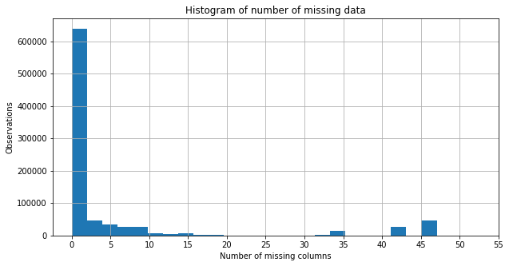

```python
plt.title('Histogram of number of missing data')
sum_row_null.hist(bins=25, figsize=(10,5))
plt.xlabel('Number of missing columns')
plt.ylabel('Observations')
plt.xticks(list(range(0, 60, 5)))
plt.show()
```

### 2. Quantify amount of missing data discarded if choose deletion strategy

- Deletion is usually not a good strategy due to loss of valuable information, the guideline is usually to delete if the proportion of missing values from our dataset is very small
- However for the purpose of this exercise, deletion is beneficial as feature cleaning/engineering may consume alot of time
- In the scree plot below, we see the first bar with almost `900k` data, which immediately drops to `250k`, this means that there are approximately `650k` data with **zero** unknown/missing values.
- As we have concluded that we will be excluding **high missing data**, the horizontal line in our scree plot explains the amount of observations relating to **high missing data**, which is approx `100k`
- As it currently stands, we then have to make a judgement call on whether to include/exclude **low/moderately missing data**, our options would be to:
  1. Only consider 0 missing data - approx 650k
  2. Consider a cut off for low/moderately missing data - approx 150k (`250k` (for 1 missing data) minus `100k` of high missing data)

```python
count_null = sum_row_null.value_counts()
cum_nul_samples = [count_null.sum()]
nul_samples = [0]
for i in range(1, count_null.shape[0] + 1):
    if i - 1 not in count_null.index:
        nul_samples.append(0)
        cum_nul_samples.append(cum_nul_samples[i - 1])
        continue
    nul_samples.append(count_null[i - 1])
    cum_nul_samples.append(cum_nul_samples[i - 1] - count_null[i - 1])
```

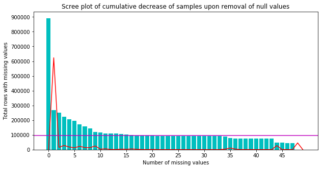

```python
plt.figure(figsize=(10, 5))
plt.title('Scree plot of cumulative decrease of samples upon removal of null values')
plt.bar(list(range(count_null.shape[0] + 1)), cum_nul_samples, color='c')
plt.plot(list(range(count_null.shape[0] + 1)), nul_samples, color='r')
plt.xlabel('Number of missing values')
plt.ylabel('Total rows with missing values')
plt.axhline(y=95000,color='m', linestyle='-')
plt.xticks(list(range(0, 50, 5)))
plt.yticks(list(range(0, 1000000, 100000)))
plt.show()
```

### 3. Analysis of feature distribution for low/moderate missing data

```python
def plot_filter_n_null(df, n_null):
    null_bool = sum_row_null <= n_null
    new_df = df[null_bool]
    tmp = get_null(new_df)
    # Only plot features with missing cells > 0
    plot_null(tmp[tmp > 0], f'Null values after removing rows with {n_null} missing features', 20, 20)
    describe_missing(tmp)
```

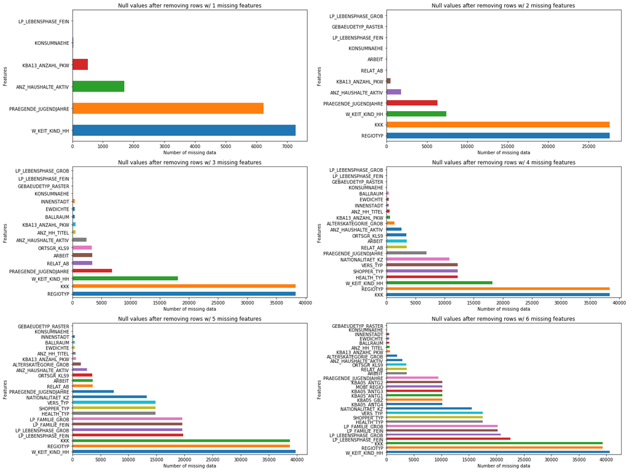

```python
plt.figure(figsize=(20,15))

for i in range(1, 7):
    plt.subplot(3, 2, i)
    # represents subplot num and also the number of missing vlaues
    null_bool = sum_row_null <= i
    null = get_null(clean_outlier_azdias[null_bool])
    null[null > 0].plot.barh()
    plt.title(f'Null values after removing rows w/ {i} missing features')
    plt.xlabel('Number of missing data')
    plt.ylabel('Features')

plt.tight_layout()
plt.show()
```

### 4. Analysis of feature distributions

#### Cut off

- As we perform our analysis below, we conclude to use a `samples with no unknown/missing values` as a cut-off as we conclude that there isn't a large difference in observation distribution between **zero and low/moderately missing features**.

```python
# Write code to divide the data into two subsets based on the number of missing
# values in each row.
zero_azdias = clean_outlier_azdias[sum_row_null == 0]
not_zero_azdias = clean_outlier_azdias[sum_row_null != 0]
clean_outlier_azdias['no_below'] = sum_row_null <= 0
```

```python
# Compare the distribution of values for at least five columns where there are
# no or few missing values, between the two subsets.

import math
# https://stackoverflow.com/questions/34615854/seaborn-countplot-with-normalized-y-axis-per-group

def plot_feature_distribution(df, feature, split_column):
    tmp_df = df.groupby(split_column)[feature].value_counts(normalize=True)
    tmp_df = tmp_df.rename('percent').reset_index()
    trans = feat_info.loc[feat_info['attribute'] == feature, 'attribute_trans']
    plt.title(f'{trans}')
    plt.ylim([0, 0.6])
    plt.legend(labels = ['no_unknown', 'unknown'])
    sns.barplot(data=tmp_df, x=feature, hue=split_column, y='percent')

def plot_feature_dist_subplots(df, feature_arr, split_column):
    subplot_size = int(math.ceil(len(feature_arr) / 2))
    plt.figure(figsize=(10, subplot_size * 5))
    for i, feature in zip(range(len(feature_arr)), feature_arr):
        plt.subplot(subplot_size, 2, i + 1)
        plot_feature_distribution(df, feature, split_column)
    plt.tight_layout()
    plt.show()
```

```python
def plot_split_dist_compare(df, feature, split_1, split_2):
    first_group = clean_outlier_azdias.groupby(split_1)[feature].value_counts(normalize=True).rename('percent')[True]
    second_group = clean_outlier_azdias.groupby(split_2)[feature].value_counts(normalize=True).rename('percent')[True]
    first = pd.DataFrame(first_group)
    first['split'] = split_1
    second = pd.DataFrame(second_group)
    second['split'] = split_2
    data=first.append(second)
    trans = feat_info.loc[feat_info['attribute'] == feature, 'attribute_trans']
    plt.title(f'{trans}')
    sns.barplot(data=data, x=data.index, hue='split', y='percent')

def plot_split_dist_subplots(df, feature_arr, split_1, split_2):
    subplot_size = int(math.ceil(len(feature_arr) / 2))
    plt.figure(figsize=(10, subplot_size * 5))
    for i, feature in zip(range(len(feature_arr)), feature_arr):
        plt.subplot(subplot_size, 2, i + 1)
        plot_split_dist_compare(df, feature, split_1, split_2)
    plt.tight_layout()
    plt.show()
```

#### Selection of features for distribution analysis

- We have noted that by filtering only for features with `zero` missing features, we are only left with `person` information. As we have analyzed earlier, the `person` information_level only makes up for 51% of our feature set.
- So instead, have expanded the number of features to `<= 20,000` to idenfiy `non-person` features. 20,000 is still a fraction of our dataset (of almost 900k)
- We have narrowed down to the following features:
  1. (person) `ANREDE_KZ` - Gender
  2. (person) `ALTERSKATEGORIE_GROB` - Estimated age based on given name analysis
  3. (household) `HH_EINKOMMEN_SCORE` - Estimated household net income
  4. (person) `FINANZTYP` - Most descriptive financial type for individual
  5. (person) `FINANZ_HAUSBAUER` - Financial typology - home ownership
  6. (region_rr1) `ONLINE_AFFINITAET` - Online Affinity

```python
feat_info[feat_info['attribute'].isin(missing_post[missing_post <= 20000].index)]
```

|  | attribute | information_level | type | missing_or_unknown | attribute_trans |
| --- | --- | --- | --- | --- | --- |
| 1 | ALTERSKATEGORIE_GROB | person | ordinal | [-1,0,9] | Estimated age based on given name analysis |
| 2 | ANREDE_KZ | person | categorical | [-1,0] | Gender |
| 3 | CJT_GESAMTTYP | person | categorical | [0] | Customer-Journey-Typology: preferred informati... |
| 4 | FINANZ_MINIMALIST | person | ordinal | [-1] | low financial interest |
| 5 | FINANZ_SPARER | person | ordinal | [-1] | Financial typology - money-saver |
| 6 | FINANZ_VORSORGER | person | ordinal | [-1] | Financial typology - be prepared |
| 7 | FINANZ_ANLEGER | person | ordinal | [-1] | Financial typology - investor |
| 8 | FINANZ_UNAUFFAELLIGER | person | ordinal | [-1] | Financial typology - inconspicuous |
| 9 | FINANZ_HAUSBAUER | person | ordinal | [-1] | Financial typology - home ownership |
| 10 | FINANZTYP | person | categorical | [-1] | Most descriptive financial type for individual |
| 12 | GFK_URLAUBERTYP | person | categorical | [] | Vacation habits |
| 13 | GREEN_AVANTGARDE | person | categorical | [] | Membership in environmental sustainability as ... |
| 19 | LP_STATUS_FEIN | person | categorical | [0] | Social status, fine scale |
| 20 | LP_STATUS_GROB | person | categorical | [0] | Social status, rough scale |
| 23 | RETOURTYP_BK_S | person | ordinal | [0] | Return type |
| 24 | SEMIO_SOZ | person | ordinal | [-1,9] | Personality typology - socially-minded |
| 25 | SEMIO_FAM | person | ordinal | [-1,9] | Personality typology - family-minded |
| 26 | SEMIO_REL | person | ordinal | [-1,9] | Personality typology - religious |
| 27 | SEMIO_MAT | person | ordinal | [-1,9] | Personality typology - materialisic |
| 28 | SEMIO_VERT | person | ordinal | [-1,9] | Personality typology - dreamful |
| 29 | SEMIO_LUST | person | ordinal | [-1,9] | Personality typology - sensual-minded |
| 30 | SEMIO_ERL | person | ordinal | [-1,9] | Personality typology - event-oriented |
| 31 | SEMIO_KULT | person | ordinal | [-1,9] | Personality typology - cultural-minded |
| 32 | SEMIO_RAT | person | ordinal | [-1,9] | Personality typology - rational |
| 33 | SEMIO_KRIT | person | ordinal | [-1,9] | Personality typology - critical-minded |
| 34 | SEMIO_DOM | person | ordinal | [-1,9] | Personality typology - dominant-minded |
| 35 | SEMIO_KAEM | person | ordinal | [-1,9] | Personality typology - combative-attitude |
| 36 | SEMIO_PFLICHT | person | ordinal | [-1,9] | Personality typology - dutiful |
| 37 | SEMIO_TRADV | person | ordinal | [-1,9] | Personality typology - traditional-minded |
| 42 | ZABEOTYP | person | categorical | [-1,9] | Energy consumption typology |
| 46 | HH_EINKOMMEN_SCORE | household | ordinal | [-1,0] | Estimated household net income |
| 72 | ONLINE_AFFINITAET | region_rr1 | ordinal | [] | Online affinity |

```python
feature_arr = ['ANREDE_KZ', 'ALTERSKATEGORIE_GROB', 'HH_EINKOMMEN_SCORE', 'FINANZTYP', 'FINANZ_HAUSBAUER', 'ONLINE_AFFINITAET']
```

#### 4.1. No missing data vs remainder with missing data

- From our analysis below:
  - **True** relates to observations with no missing data
    - we will call this `NO-UNKNOWN` for the purpose of this analysis
  - **False** has missing data
    - we call this `UNKNOWN`
- The proportions of the elements in each feature is scaled so they would sum up to a `100%`

**Observations**

1. Gender - `ANREDE_KZ`
   - **1 and 2** relates to Male and Female respectively
   - Gender split seems to be similar, both datasets show that there are more females than males
   - `UNKNOWN` has a higher proportion of females compared to `NO_UNKNOWN`
2. Estimated Age - `ALTERSKATEGORIE_GROB`
   - Labels **1 and 2** relates to ages from 1 up until 45 years old. Both data sets seem to have similar proportions
   - However, `UNKNOWN` has higher proportion of category 3, i.e. individuals aging from `46-60`, while `NO_UNKNOWN` is higher in category 4, i.e. individuals `> 60 years old`
   - This suggests that our `UNKNOWN` data set is a younger demographic. While `NO_UNKNOWN` has more elderly.
3. Estimated household net income - `HH_EINKOMMEN_SCORE`
   - For `NO_UNKNOWN`, we observe an exponential curve from low score (being highest income) to a high score (being low income)
   - Although proportions for category 1, i.e. `highest income` is pretty similar between our subsets, category 2, `very high income` in `UNKNOWN` covers a significant proportion (almost 40%) for this dataset.
4. Most descriptive financial type for individual - `FINANZTYP`
   - Distributions seem similar for subsets, forming a `U` curve, with a low scare having low financial interest, and high end being (invest and inconspicuous)
   - The `UNKNOWN` has a significant proportion in category 4, `be prepared` of > 30%
5. Financial Typology - Home Ownership - `FINANZ_HAUSBAUER`
   - pretty evenly distributed for `NO_UNKNOWN` but
   - `UNKNOWN` has a significant proportion in category 3, having average financial typology - home ownership
6. Online Affinity - `ONLINE_AFFINITAET`
   - pretty evenly distributed for `NO_UNKNOWN` (with minority of population with low affinity), but
   - `UNKNOWN` has a significant proportion in category 2, having middle online affinity

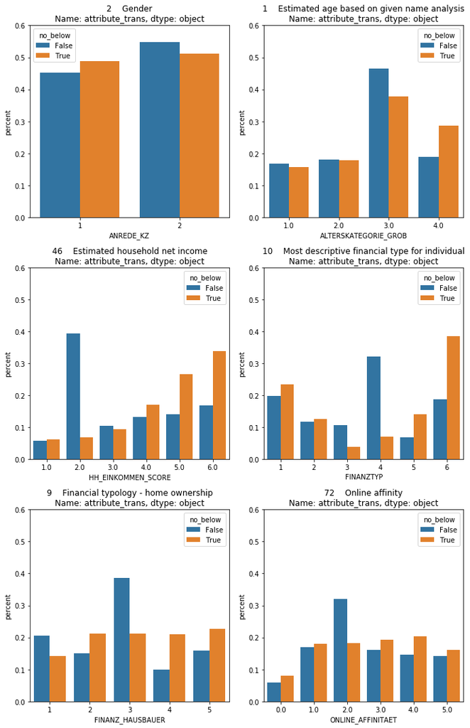

```python
plot_feature_dist_subplots(clean_outlier_azdias, feature_arr, 'no_below')
```

#### 4.1.1 Extra

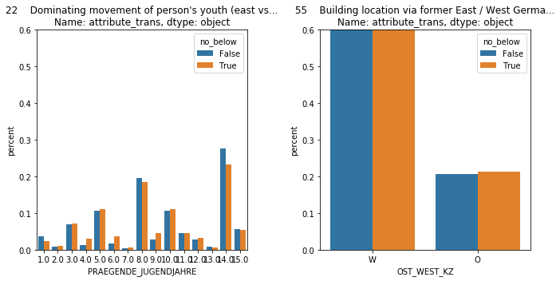

```python
plot_feature_dist_subplots(clean_outlier_azdias, ['PRAEGENDE_JUGENDJAHRE', 'OST_WEST_KZ'], 'no_below')
```

```python
clean_outlier_azdias['no_below'] = sum_row_null <= 0
clean_outlier_azdias['two_below'] = sum_row_null <= 2
clean_outlier_azdias['ten_below'] = sum_row_null <= 10
```

#### 4.2. Zero missing data vs Low/moderate missing data

**4.2.1 Zero Low missing data vs Low missing data (2 as cut-off)**

- We have concluded to utilise 2 as a cut-off previously
- Our analysis below shows that the distributions are **still very similar**, so it would make sense just to use the subset with no missing data

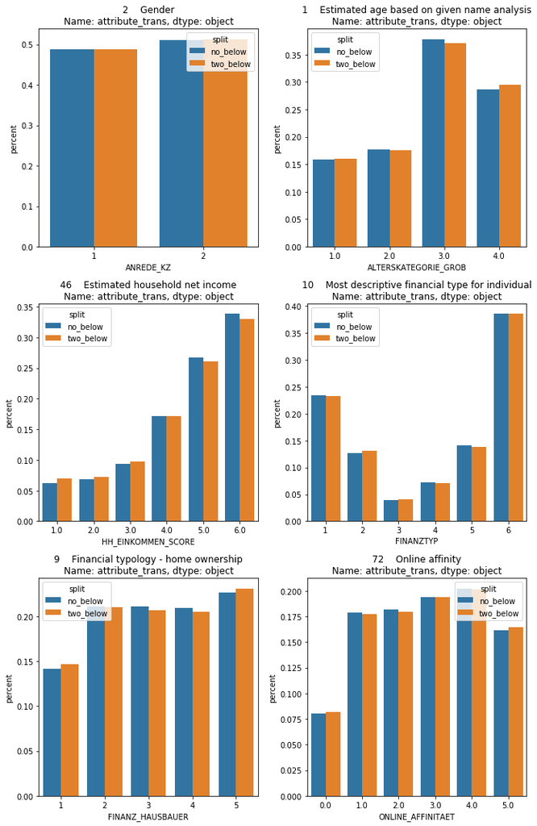

```python
plot_split_dist_subplots(clean_outlier_azdias, feature_arr, 'no_below', 'two_below')
```

**4.2.2 Zero Low missing data vs Moderate missing data (10 as cut-off)**

- We already concluded that using 4 and above as a cut-off would not be feasible in terms of this project
- Our analysis below still shows that the distributions are **similar** even comparing with a subset with 10 moderate missing data

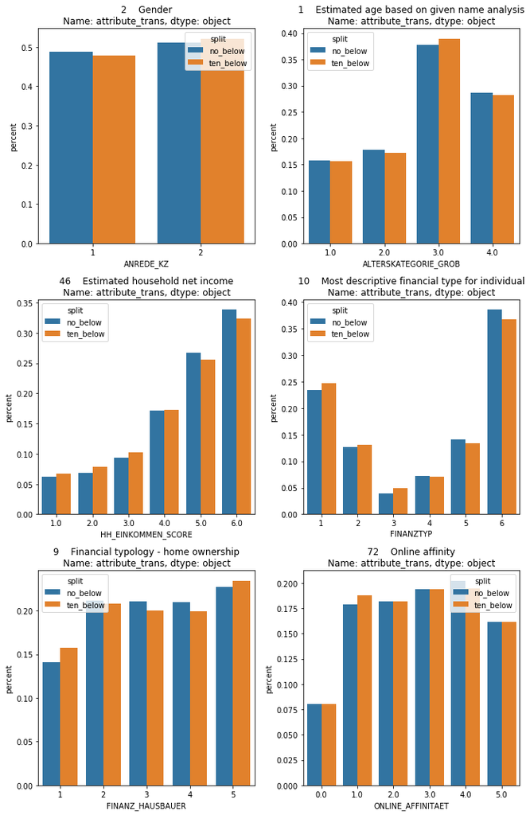

```python
plot_split_dist_subplots(clean_outlier_azdias, feature_arr, 'no_below', 'ten_below')
```

```python
# Un-comment below to show comparison with a larger number of attributes

# attributes = feat_info[feat_info['attribute'].isin(missing_post[missing_post <= 50000].index)]['attribute']
# attributes
# # Compare no missing with 10 as cut-off
# plot_split_dist_subplots(clean_outlier_azdias, attributes, 'no_below', 'ten_below')
# # Compare no missing with 2 as cut-off
# plot_split_dist_subplots(clean_outlier_azdias, attributes, 'no_below', 'two_below')
```

#### Discussion 1.1.3: Assess Missing Data in Each Row

**Conclusion from 4.1** No missing data vs remainder with missing data

- In summary, our `UNKNOWN` subset:
  - has slightly higher proportion of females to males
  - is younger where there are more middle aged people (46-60) than elderly
  - is wealthier in terms of household net income
  - seems more conservative where its financial inclinations is to 'be prepared'
  - prioritises home ownership more than the other subset
  - has higher proportion of people with average affinity with the internet
- As mentioned, we will not include this subset in our modelling, but it was interesting to observe that there are clear contrasts between each subset

**Conclusion from 4.2** No missing data vs cut-off with 2 and 10 missing data

- Our analysis indicates that our data distribution is still very much retained
- We conclude to utilise the subset with no missing data `zero_azdias` for our modelling

### Step 1.2: Select and Re-Encode Features

Checking for missing data isn't the only way in which you can prepare a dataset for analysis. Since the unsupervised learning techniques to be used will only work on data that is encoded numerically, you need to make a few encoding changes or additional assumptions to be able to make progress. In addition, while almost all of the values in the dataset are encoded using numbers, not all of them represent numeric values. Check the third column of the feature summary (`feat_info`) for a summary of types of measurement.

- For numeric and interval data, these features can be kept without changes.
- Most of the variables in the dataset are ordinal in nature. While ordinal values may technically be non-linear in spacing, **make the simplifying assumption that the ordinal variables can be treated as being interval in nature** (that is, kept without any changes).
- Special handling may be necessary for the remaining two variable types: categorical, and 'mixed'.

In the first two parts of this sub-step, you will perform an investigation of the categorical and mixed-type features and make a decision on each of them, whether you will keep, drop, or re-encode each. Then, in the last part, you will create a new data frame with only the selected and engineered columns.

Data wrangling is often the trickiest part of the data analysis process, and there's a lot of it to be done here. But stick with it: once you're done with this step, you'll be ready to get to the machine learning parts of the project!

#### We drop features with high number of missing values

### A. Spread of data

- `numeric` data will remain as is, and will immediately proceed to feature scaling in the next step
- After removing feature with high number of missing values, we still observe that `ordinal` features contribute to a large majority of our featureset
  - As mentioned above, we will make the simple assumption that orinal variables can be treated as being interval, so no further re-encoding or engineering will be performed over this type of data
- `categorical` features can be sub-divided into the following, where different strategies will be employed over them:
  1. binary - i.e. just 2 labels
  2. low cardinality - low number of unique labels
  3. moderate/high cardinality, higher number of unique labels
- `mixed` variables require additional considerations which are not clear cut, of which we will be revisiting subsequently

```python
# reset zero_azdias index
# drop=True
# https://stackoverflow.com/questions/16167829/in-pandas-how-can-i-reset-index-without-adding-a-new-column
zero_azdias.reset_index(inplace=True, drop=True)
```

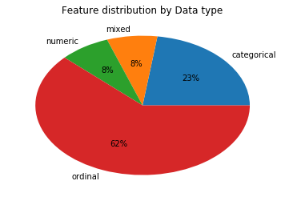

```python
# How many features are there of each data type?
new_feat_info = feat_info[~feat_info['attribute'].isin(more_300k.index)]
new_features = new_feat_info.groupby('type').count()
new_type_count = new_features['attribute']
new_feature_names = new_features.index

plt.title('Feature distribution by Data type')
plt.pie(new_type_count, labels=new_feature_names, autopct='%.0f%%')
plt.show()
```

#### Step 1.2.1: Re-Encode Categorical Features

For categorical data, you would ordinarily need to encode the levels as dummy variables. Depending on the number of categories, perform one of the following:

- For `binary (two-level)` categoricals that take numeric values, you can keep them without needing to do anything.
  - There is one binary variable that takes on non-numeric values. For this one, you need to re-encode the values as numbers or create a dummy variable.
- For multi-level categoricals (three or more values), you can choose to encode the values using multiple dummy variables (e.g. via [OneHotEncoder](http://scikit-learn.org/stable/modules/generated/sklearn.preprocessing.OneHotEncoder.html)), or (to keep things straightforward) just drop them from the analysis. As always, document your choices in the Discussion section.

### B. Strategy for categorical features

1. General guidelines
   - binary - remain
   - low cardinality - to one hot encode
   - moderate and high cardinality - to remove
2. Specific guidelines
   - remain for features which are `somewhat_ordinal` upon inspection of Data Dictionary
   - remove features which seem like duplicates

```python
# Assess categorical variables: which are binary, which are multi-level, and
# which one needs to be re-encoded?

def filter_info_clean(type_name):
    return feat_info[(feat_info['attribute'].isin(zero_azdias.columns)) & (feat_info['type'] == type_name)]

somewhat_ordinal = ['LP_FAMILIE_FEIN', 'LP_STATUS_FEIN', 'CAMEO_DEUG_2015']
# LP_FAMILIE_GROB can be mapped to LP_FAMILIE_FEIN
# LP_STATUS_GROB can be mapped to LP_STATUS_FEIN
# GEBAEUDETYP - feature set already has feature describing this, i.e. GEBAEUDETYP_RASTER
to_remove = ['LP_FAMILIE_GROB', 'LP_STATUS_GROB', 'GEBAEUDETYP']

def bucket_categorical(elem):
    if elem == 2:
        return 'binary'
    elif elem <= 5:
        return 'low'
    elif elem <= 10:
        return 'moderate'
    return 'high'

def map_categorical_strategy(row):
    att = row['attribute']
    card = row['cardinality']
    if att in somewhat_ordinal or card == 'binary':
        return 'do nothing'
    elif att in to_remove or card in ['moderate', 'high']:
        return 'delete'
    elif card == 'low':
        return 'one-hot encode'
    return elem
```

```python
categorical_features = filter_info_clean('categorical')[['attribute', 'attribute_trans']]

# Number of unique labels based on Data_Dictionary.md
labels = [2, 6, 6, 12, 2, 11, 5, 10, 5, 3, 4, 2, 2, 6, 5, 2, 9, 44]
categorical_features['unique'] = labels
categorical_features['cardinality'] = categorical_features['unique'].apply(bucket_categorical)
categorical_features['strategy'] = categorical_features.apply(map_categorical_strategy, axis=1)
categorical_features
```

|  | attribute | attribute_trans | unique | cardinality | strategy |
| --- | --- | --- | --- | --- | --- |
| 2 | ANREDE_KZ | Gender | 2 | binary | do nothing |
| 3 | CJT_GESAMTTYP | Customer-Journey-Typology: preferred informati... | 6 | moderate | delete |
| 10 | FINANZTYP | Most descriptive financial type for individual | 6 | moderate | delete |
| 12 | GFK_URLAUBERTYP | Vacation habits | 12 | high | delete |
| 13 | GREEN_AVANTGARDE | Membership in environmental sustainability as ... | 2 | binary | do nothing |
| 17 | LP_FAMILIE_FEIN | Family type, fine scale | 11 | high | do nothing |
| 18 | LP_FAMILIE_GROB | Family type, rough scale | 5 | low | delete |
| 19 | LP_STATUS_FEIN | Social status, fine scale | 10 | moderate | do nothing |
| 20 | LP_STATUS_GROB | Social status, rough scale | 5 | low | delete |
| 21 | NATIONALITAET_KZ | Nationality based on given name analysis | 3 | low | one-hot encode |
| 38 | SHOPPER_TYP | Shopper typology | 4 | low | one-hot encode |
| 39 | SOHO_KZ | Small office / home office flag | 2 | binary | do nothing |
| 41 | VERS_TYP | Insurance typology | 2 | binary | do nothing |
| 42 | ZABEOTYP | Energy consumption typology | 6 | moderate | delete |
| 52 | GEBAEUDETYP | Type of building (residencommercial) | 5 | low | delete |
| 55 | OST_WEST_KZ | Building location via former East / West Germa... | 2 | binary | do nothing |
| 57 | CAMEO_DEUG_2015 | German CAMEO: Wealth / Life Stage Typology, ro... | 9 | moderate | do nothing |
| 58 | CAMEO_DEU_2015 | German CAMEO: Wealth / Life Stage Typology, de... | 44 | high | delete |

### B.1 - Drop columns

```python
to_drop_categorical = categorical_features[categorical_features['strategy'] == 'delete']['attribute']
to_drop_categorical
```

```
3       CJT_GESAMTTYP
10          FINANZTYP
12    GFK_URLAUBERTYP
18    LP_FAMILIE_GROB
20     LP_STATUS_GROB
42           ZABEOTYP
52        GEBAEUDETYP
58     CAMEO_DEU_2015
Name: attribute, dtype: object
```

```python
zero_azdias.shape
```

```
(623209, 79)
```

```python
zero_azdias = zero_azdias.drop(to_drop_categorical, axis=1)
zero_azdias.shape
```

```
(623209, 71)
```

### B.2 - Update column to numerical form

#### Update `OST_WEST_KZ`

- 0 = E(ast)
- 1 = W(est)

```python
# Before
zero_azdias['OST_WEST_KZ'].value_counts()
```

```
W    490879
O    132330
Name: OST_WEST_KZ, dtype: int64
```

```python
zero_azdias['OST_WEST_KZ'] = zero_azdias['OST_WEST_KZ'].map({'O' : 0, 'W' : 1})
zero_azdias['OST_WEST_KZ'].value_counts()
```

```
1    490879
0    132330
Name: OST_WEST_KZ, dtype: int64
```

```python
zero_azdias.shape
```

```
(623209, 71)
```

### B.3 - One hot encode low cardinality categoricals

- `NATIONALITAET_KZ`
- `SHOPPER_TYP`

```python
# Re-encode categorical variable(s) to be kept in the analysis.

from sklearn.preprocessing import OneHotEncoder
one_hot = OneHotEncoder()
encoded_res = pd.DataFrame(one_hot.fit_transform(zero_azdias[['NATIONALITAET_KZ', 'SHOPPER_TYP']]).toarray())
```

```python
# indices = one_hot.feature_indices_
indices = [0, 3, 7]
one_hot_labels = []
for i in range(len(indices) - 1):
    for j in range(0, indices[i + 1] - indices[i]):
        one_hot_labels.append(f'feat{i+1}_{j+1}')
len(one_hot_labels)
```

```
7
```

```python
def update_with_encoded(df, encoded, features):
    tmp_df = df.copy()
    tmp_df.drop(features, axis=1, inplace=True)
    encoded.columns = one_hot_labels
    tmp_df = tmp_df.merge(encoded, how='left', left_index=True, right_index=True)
    return tmp_df
```

```python
zero_azdias = update_with_encoded(zero_azdias, encoded_res, features=['NATIONALITAET_KZ', 'SHOPPER_TYP'])
zero_azdias.shape
```

```
(623209, 76)
```

#### Discussion 1.2.1: Re-Encode Categorical Features

- An assessment was made based on the cardinality of the categorical features to determine if we were to:
  1. delete
  2. one-hot encode
  3. do nothing
- Binary categorical features do not require further action, so no further action will be required
- We only consider low cardinal value categorical features to one hot encode since it will take considerable time for our algorithms to run considering the size of our dataset, a cut-off of 5 is taken
- Moderate or high cardinal features are removed due to the reason above
- Further inspection has been made over the Data_Dictionary to confirm if there are **repeating categorical features**, of which we can remove one of them, there are also some features which **seem somewhat ordinal in nature**, so we will remain them as well.

#### Step 1.2.2: Engineer Mixed-Type Features

There are a handful of features that are marked as "mixed" in the feature summary that require special treatment in order to be included in the analysis. There are two in particular that deserve attention; the handling of the rest are up to your own choices:

- "PRAEGENDE_JUGENDJAHRE" combines information on three dimensions: generation by decade, movement (mainstream vs. avantgarde), and nation (east vs. west). While there aren't enough levels to disentangle east from west, you should create two new variables to capture the other two dimensions: an interval-type variable for decade, and a binary variable for movement.
- "CAMEO_INTL_2015" combines information on two axes: wealth and life stage. Break up the two-digit codes by their 'tens'-place and 'ones'-place digits into two new ordinal variables (which, for the purposes of this project, is equivalent to just treating them as their raw numeric values).
- If you decide to keep or engineer new features around the other mixed-type features, make sure you note your steps in the Discussion section.

Be sure to check `Data_Dictionary.md` for the details needed to finish these tasks.

### C. Strategy for Mixed features

- Both `LP_LEBENSPHASE_FEIN` and `LP_LEBENSPHASE_GROB` are related to each other
  - they both relate to life stages
  - Unfortunately they do not have a direct ordinal quality in them
  - It is possible to feature engineer but for the scope of this project and time constraints, we will be dropping these features
    - Also, we can rely on `CAMEO_INTL_2015` below to somewhat explain lifestages too
- `PRAEGENDE_JUGENDJAHRE`, `CAMEO_INTL_2015`, `PLZ8_BAUMAX` - refer to detailed explanations below

```python
# Total remaining mixed features
mixed_features = filter_info_clean('mixed')[['attribute', 'attribute_trans']]
mixed_features
```

|  | attribute | attribute_trans |
| --- | --- | --- |
| 15 | LP_LEBENSPHASE_FEIN | Life stage, fine scale |
| 16 | LP_LEBENSPHASE_GROB | Life stage, rough scale |
| 22 | PRAEGENDE_JUGENDJAHRE | Dominating movement of person's youth (east vs... |
| 56 | WOHNLAGE | Neighborhood quality (or rural flag) |
| 59 | CAMEO_INTL_2015 | German CAMEO: Wealth / Life Stage Typology, ma... |
| 79 | PLZ8_BAUMAX | Most common building type within the PLZ8 region |

### C.1 `PRAEGENDE_JUGENDJAHRE` - Dominating movement of person's youth

- There is a mix of 3 features within, and only 2 can be easily distinguishable, so we only engineer these 2
  - Domimating year
  - Mainstream / Avantgarde
- East / West cannot be easily distinguished

```python
'''
From Data_Dictionary.md

-  1: 40s - war years (Mainstream, E+W)
-  2: 40s - reconstruction years (Avantgarde, E+W)
-  3: 50s - economic miracle (Mainstream, E+W)
-  4: 50s - milk bar / Individualisation (Avantgarde, E+W)
-  5: 60s - economic miracle (Mainstream, E+W)
-  6: 60s - generation 68 / student protestors (Avantgarde, W)
-  7: 60s - opponents to the building of the Wall (Avantgarde, E)
-  8: 70s - family orientation (Mainstream, E+W)
-  9: 70s - peace movement (Avantgarde, E+W)
- 10: 80s - Generation Golf (Mainstream, W)
- 11: 80s - ecological awareness (Avantgarde, W)
- 12: 80s - FDJ / communist party youth organisation (Mainstream, E)
- 13: 80s - Swords into ploughshares (Avantgarde, E)
- 14: 90s - digital media kids (Mainstream, E+W)
- 15: 90s - ecological awareness (Avantgarde, E+W)
'''

# 1 = Mainstream, 0 = Avantgarde
# mapped [year, mainstream/avantgarde]
PRAEGENDE_dict = {
    1: [1940, 1],
    2: [1940, 0],
    3: [1950, 1],
    4: [1950, 0],
    5: [1960, 1],
    6: [1960, 0],
    7: [1960, 0],
    8: [1970, 1],
    9: [1970, 0],
    10: [1980, 1],
    11: [1980, 0],
    12: [1980, 1],
    13: [1980, 0],
    14: [1990, 1],
    15: [1990, 0]
}
```

### C.2 `CAMEO_INTL_2015` - German CAMEO: Wealth / Life Stage Typology, mapped to international code

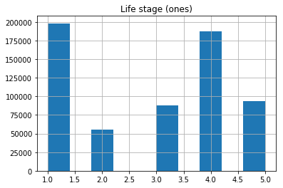

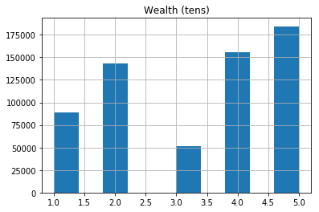

```python
# Investigate "CAMEO_INTL_2015" and engineer two new variables.
'''
- -1: unknown
- 11: Wealthy Households - Pre-Family Couples & Singles
- 12: Wealthy Households - Young Couples With Children
- 13: Wealthy Households - Families With School Age Children
- 14: Wealthy Households - Older Families &  Mature Couples
- 15: Wealthy Households - Elders In Retirement
- 21: Prosperous Households - Pre-Family Couples & Singles
- 22: Prosperous Households - Young Couples With Children
- 23: Prosperous Households - Families With School Age Children
- 24: Prosperous Households - Older Families & Mature Couples
- 25: Prosperous Households - Elders In Retirement
- 31: Comfortable Households - Pre-Family Couples & Singles
- 32: Comfortable Households - Young Couples With Children
- 33: Comfortable Households - Families With School Age Children
- 34: Comfortable Households - Older Families & Mature Couples
- 35: Comfortable Households - Elders In Retirement
- 41: Less Affluent Households - Pre-Family Couples & Singles
- 42: Less Affluent Households - Young Couples With Children
- 43: Less Affluent Households - Families With School Age Children
- 44: Less Affluent Households - Older Families & Mature Couples
- 45: Less Affluent Households - Elders In Retirement
- 51: Poorer Households - Pre-Family Couples & Singles
- 52: Poorer Households - Young Couples With Children
- 53: Poorer Households - Families With School Age Children
- 54: Poorer Households - Older Families & Mature Couples
- 55: Poorer Households - Elders In Retirement
'''
plt.title('Life stage (ones)')
(zero_azdias['CAMEO_INTL_2015'].astype(int) % 10).hist()
plt.show()
plt.title('Wealth (tens)')
(zero_azdias['CAMEO_INTL_2015'].astype(int) // 10).hist()
plt.show()
```

### C.3 `PLZ8_BAUMAX` - Most common building type within the PLZ8 region

- 2 new features will be created:
  1. n_family_homes - represented by 1 to 4 tagging below
     - tagging `5` which relates to 'mainly business buildings' will be assigned a 0 tagging
  2. family_or_business - represented by binary
     - 1 = family, 0 = business

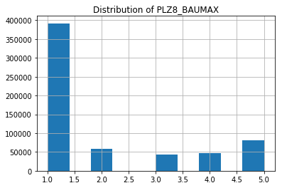

```python
'''
-  1: mainly 1-2 family homes
-  2: mainly 3-5 family homes
-  3: mainly 6-10 family homes
-  4: mainly 10+ family homes
-  5: mainly business buildings
'''
plt.title('Distribution of PLZ8_BAUMAX')
zero_azdias['PLZ8_BAUMAX'].hist()
plt.show()
```

### C.4 `WOHNLAGE` - Neighborhood quality (or rural flag)

- 2 new features will be created
  1. `is_rural`
     - 1 if label is `7 or 8`, 0 otherwise
  2. `neighborhood_score`
     - We can assign scores 0 to 7 by default to `non-rural` neighborhoods
     - However we need to make a call over how to distribute the `7 and 8` rural scores
     - An option is to assign them all to no score calculated, to assign to an average score of 3
     - I have inspected the `REGIOTYP` - Neighborhood typology which explains the class of a neighborhood, the distribution in this feature that our dataset is skewed to the right, i.e. high proportions are `lower middle class/traditional workers`
     - Hence, we assign our rural labellings of `7 / 8` to `4 - poor neighborhood`

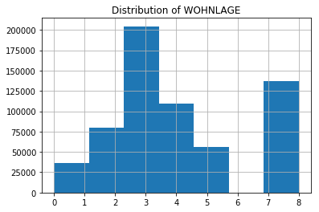

```python
'''
-  0: no score calculated
-  1: very good neighborhood
-  2: good neighborhood
-  3: average neighborhood
-  4: poor neighborhood
-  5: very poor neighborhood
-  7: rural neighborhood
-  8: new building in rural neighborhood
'''
plt.title('Distribution of WOHNLAGE')
zero_azdias['WOHNLAGE'].hist(bins=7)
plt.show()
```

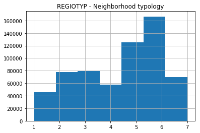

```python
plt.title('REGIOTYP - Neighborhood typology')
zero_azdias['REGIOTYP'].hist(bins=7)
plt.show()
```

### C4.1 - Updated `WOHNLAGE`

- Here we see that the distribution of WOHNLAGE and REGIOTYP is somewhat similarly distributed

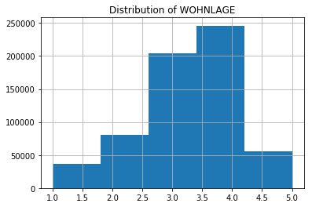

```python
def update_wohnlage(elem):
    if elem in [7, 8]:
        return 4
    elif elem == 0:
        return 3
    return elem

(zero_azdias['WOHNLAGE'].apply(update_wohnlage)).hist(bins=5)
plt.title('Distribution of WOHNLAGE')
plt.show()
```

```python
def update_mixed(df):
    tmp = df.copy()
    # C - Remove mixed columns
    tmp.drop(['LP_LEBENSPHASE_FEIN', 'LP_LEBENSPHASE_GROB'], axis=1, inplace=True)
    # C.1 - PRAEGENDE_JUGENDJAHRE
    # Note: removed pd.to_datetime(df)
    tmp['defining_years'] = tmp['PRAEGENDE_JUGENDJAHRE'].apply(lambda x : PRAEGENDE_dict[x][0])
    tmp['mainstream_avantgarde'] = tmp['PRAEGENDE_JUGENDJAHRE'].apply(lambda x: PRAEGENDE_dict[x][1])
    # C.2 - CAMEO_INTL_2015
    tmp['CAMEO_INTL_2015'] = tmp['CAMEO_INTL_2015'].astype(float)
    tmp['wealth'] = tmp['CAMEO_INTL_2015'] // 10
    tmp['life_stage'] = tmp['CAMEO_INTL_2015'] % 10
    # C.3 - PLZ8_BAUMAX
    tmp['n_family_homes'] = tmp['PLZ8_BAUMAX'].apply(lambda x : 0 if x == 5 else x)
    tmp['family_or_business'] = tmp['PLZ8_BAUMAX'].apply(lambda x : 0 if x == 5 else 1)
    # C.4 - WOHNLAGE
    tmp['is_rural'] = tmp['WOHNLAGE'].apply(lambda x : 1 if x in [7, 8] else 0)
    tmp['neighborhood_score'] = tmp['WOHNLAGE'].apply(update_wohnlage)
    # Drop additional unnecessary columns above
    tmp.drop(['PRAEGENDE_JUGENDJAHRE', 'CAMEO_INTL_2015', 'PLZ8_BAUMAX', 'WOHNLAGE'], axis=1, inplace=True)
    return tmp
```

```python
zero_azdias.shape
```

```
(623209, 76)
```

```python
zero_azdias = update_mixed(zero_azdias)
zero_azdias.shape
```

```
(623209, 78)
```

#### Discussion 1.2.2: Engineer Mixed-Type Features

#### Summary from above

- C - removed columns `LP_LEBENSPHASE_FEIN`, `LP_LEBENSPHASE_GROB` since they relate to life cycles and can be explained by feature CAMEO_INTL_2015
- C.1 - feature engineered `defining_years` and `mainstream_avantgarde` from 'PRAEGENDE_JUGENDJAHRE'
- C.2 - feature engineered `wealth` and `life_stage` from CAMEO_INTL_2015
- C.3 - feature engineered `n_family_homes` and `family_or_business` from PLZ8_BAUMAX
- C.4 - feature engineered `is_rural` and `neighborhood_score` from WOHNLAGE
- kindly refer above cells for justifications of feature engineering

#### Step 1.2.3: Complete Feature Selection

In order to finish this step up, you need to make sure that your data frame now only has the columns that you want to keep. To summarize, the dataframe should consist of the following:

- All numeric, interval, and ordinal type columns from the original dataset.
- Binary categorical features (all numerically-encoded).
- Engineered features from other multi-level categorical features and mixed features.

Make sure that for any new columns that you have engineered, that you've excluded the original columns from the final dataset. Otherwise, their values will interfere with the analysis later on the project. For example, you should not keep "PRAEGENDE_JUGENDJAHRE", since its values won't be useful for the algorithm: only the values derived from it in the engineered features you created should be retained. As a reminder, your data should only be from **the subset with few or no missing values**.

```python
# If there are other re-engineering tasks you need to perform, make sure you
# take care of them here. (Dealing with missing data will come in step 2.1.)

# Inspection of dataframe datatypes which are not int or floats
zero_azdias.select_dtypes(exclude=['int64', 'float64']).columns
```

```
Index(['CAMEO_DEUG_2015'], dtype='object')
```

### D. Convert `CAMEO_DEUG_2015` to int

- As we concluded that this featureset is ordinal in nature, we will label as an integer

```python
zero_azdias['CAMEO_DEUG_2015'] = zero_azdias['CAMEO_DEUG_2015'].astype(int)
zero_azdias['CAMEO_DEUG_2015'].value_counts()
```

```
8    113915
9     87295
6     87089
4     80020
3     63525
7     61735
2     59442
5     41070
1     29118
Name: CAMEO_DEUG_2015, dtype: int64
```

```python
# Confirming number of features remaining
_high_unknown = 6
_removed_categorical = 8
_onehot_new_cols = 7
_onehot_removed_cols = 2
_mixed_removed = 2
_mixed_eng = 8
_mixed_eng_removed = 4

azdias.shape[1] - _high_unknown - _removed_categorical + _onehot_new_cols - _onehot_removed_cols - _mixed_removed + _mixed_eng - _mixed_eng_removed
```

```
78
```

```python
zero_azdias.shape
```

```
(623209, 78)
```

### Step 1.3: Create a Cleaning Function

Even though you've finished cleaning up the general population demographics data, it's important to look ahead to the future and realize that you'll need to perform the same cleaning steps on the customer demographics data. In this substep, complete the function below to execute the main feature selection, encoding, and re-engineering steps you performed above. Then, when it comes to looking at the customer data in Step 3, you can just run this function on that DataFrame to get the trimmed dataset in a single step.

```python
def clean_data(df):
    """
    Perform feature trimming, re-encoding, and engineering for demographics
    data

    INPUT: Demographics DataFrame
    OUTPUT: Trimmed and cleaned demographics DataFrame
    """
    tmp = df.copy()
    # convert missing value codes into NaNs, ...
    tmp = df_make_na(tmp)

    # Remove outlier columns
    tmp = tmp.drop(more_300k.index, axis=1)
    # remove rows with missing data
    sum_row_null = tmp.isnull().sum(axis=1)
    tmp = tmp[sum_row_null == 0]
    tmp.reset_index(inplace=True, drop=True)

    # select, re-encode, and engineer column values.
    # B.1 Drop columns
    tmp.drop(to_drop_categorical, axis=1, inplace=True)

    # B.2 East/West
    tmp['OST_WEST_KZ'] = tmp['OST_WEST_KZ'].map({'O' : 0, 'W' : 1})

    # B.3 Categorical columns to onehot encode
    res = pd.DataFrame()
    # transform, not fit_transform
    encoded_res = pd.DataFrame(one_hot.transform(tmp[['NATIONALITAET_KZ', 'SHOPPER_TYP']]).toarray())
    tmp = update_with_encoded(tmp, encoded_res, features=['NATIONALITAET_KZ', 'SHOPPER_TYP'])

    # C. Feature enginnering mixed
    tmp = update_mixed(tmp)

    # Label encode
    tmp['CAMEO_DEUG_2015'] = tmp['CAMEO_DEUG_2015'].astype(int)
    # Return the cleaned dataframe.
    return tmp
```

```python
test = clean_data(azdias)
test.equals(zero_azdias)
```

```
True
```

## Step 2: Feature Transformation

### Step 2.1: Apply Feature Scaling

Before we apply dimensionality reduction techniques to the data, we need to perform feature scaling so that the principal component vectors are not influenced by the natural differences in scale for features. Starting from this part of the project, you'll want to keep an eye on the [API reference page for sklearn](http://scikit-learn.org/stable/modules/classes.html) to help you navigate to all of the classes and functions that you'll need. In this substep, you'll need to check the following:

- sklearn requires that data not have missing values in order for its estimators to work properly. So, before applying the scaler to your data, make sure that you've cleaned the DataFrame of the remaining missing values. This can be as simple as just removing all data points with missing data, or applying an [Imputer](https://scikit-learn.org/0.16/modules/generated/sklearn.preprocessing.Imputer.html) to replace all missing values. You might also try a more complicated procedure where you temporarily remove missing values in order to compute the scaling parameters before re-introducing those missing values and applying imputation. Think about how much missing data you have and what possible effects each approach might have on your analysis, and justify your decision in the discussion section below.
- For the actual scaling function, a [StandardScaler](http://scikit-learn.org/stable/modules/generated/sklearn.preprocessing.StandardScaler.html) instance is suggested, scaling each feature to mean 0 and standard deviation 1.
- For these classes, you can make use of the `.fit_transform()` method to both fit a procedure to the data as well as apply the transformation to the data at the same time. Don't forget to keep the fit sklearn objects handy, since you'll be applying them to the customer demographics data towards the end of the project.

```python
# Apply feature scaling to the general population demographics data.
from sklearn.preprocessing import StandardScaler
standard_scaler = StandardScaler()
scaled_azdias = pd.DataFrame(standard_scaler.fit_transform(zero_azdias))
scaled_azdias.columns = zero_azdias.columns
```

```python
scaled_azdias.describe(include='all')
```

|  | ALTERSKATEGORIE_GROB | ANREDE_KZ | FINANZ_MINIMALIST | FINANZ_SPARER | FINANZ_VORSORGER | FINANZ_ANLEGER | FINANZ_UNAUFFAELLIGER | FINANZ_HAUSBAUER | GREEN_AVANTGARDE | HEALTH_TYP | ... | feat2_3 | feat2_4 | defining_years | mainstream_avantgarde | wealth | life_stage | n_family_homes | family_or_business | is_rural | neighborhood_score |
| --- | --- | --- | --- | --- | --- | --- | --- | --- | --- | --- | --- | --- | --- | --- | --- | --- | --- | --- | --- | --- | --- |
| count | 6.232090e+05 | 6.232090e+05 | 6.232090e+05 | 6.232090e+05 | 6.232090e+05 | 6.232090e+05 | 6.232090e+05 | 6.232090e+05 | 6.232090e+05 | 6.232090e+05 | ... | 6.232090e+05 | 6.232090e+05 | 6.232090e+05 | 6.232090e+05 | 6.232090e+05 | 6.232090e+05 | 6.232090e+05 | 6.232090e+05 | 6.232090e+05 | 6.232090e+05 |
| mean | 9.230537e-17 | -2.158277e-17 | 1.261674e-16 | 1.374262e-16 | 1.478300e-16 | 3.104019e-18 | 7.332212e-17 | 1.068934e-16 | 8.841751e-18 | -2.007779e-16 | ... | -7.576771e-17 | -7.165752e-18 | 7.429631e-15 | -4.929091e-17 | 1.881224e-18 | -3.490953e-17 | 5.664193e-17 | 9.050966e-17 | 7.509503e-17 | 1.299013e-16 |
| std | 1.000001e+00 | 1.000001e+00 | 1.000001e+00 | 1.000001e+00 | 1.000001e+00 | 1.000001e+00 | 1.000001e+00 | 1.000001e+00 | 1.000001e+00 | 1.000001e+00 | ... | 1.000001e+00 | 1.000001e+00 | 1.000001e+00 | 1.000001e+00 | 1.000001e+00 | 1.000001e+00 | 1.000001e+00 | 1.000001e+00 | 1.000001e+00 | 1.000001e+00 |
| min | -1.746291e+00 | -1.022678e+00 | -1.512224e+00 | -1.141401e+00 | -1.765051e+00 | -1.221857e+00 | -1.139028e+00 | -1.588887e+00 | -5.536702e-01 | -1.591638e+00 | ... | -6.300054e-01 | -5.448443e-01 | -2.280180e+00 | -1.806129e+00 | -1.595957e+00 | -1.251108e+00 | -1.281354e+00 | -2.575292e+00 | -5.306704e-01 | -2.317583e+00 |
| 25% | -7.720918e-01 | -1.022678e+00 | -7.773472e-01 | -1.141401e+00 | -1.045042e+00 | -1.221857e+00 | -1.139028e+00 | -8.565448e-01 | -5.536702e-01 | -2.734958e-01 | ... | -6.300054e-01 | -5.448443e-01 | -9.023264e-01 | 5.536702e-01 | -9.099974e-01 | -1.251108e+00 | -3.182819e-01 | 3.883055e-01 | -5.306704e-01 | -3.274094e-01 |
| 50% | 2.021075e-01 | 9.778248e-01 | -4.247059e-02 | 2.198282e-01 | 3.949756e-01 | 1.586008e-01 | -4.103275e-01 | -1.242026e-01 | -5.536702e-01 | -2.734958e-01 | ... | -6.300054e-01 | -5.448443e-01 | -2.133995e-01 | 5.536702e-01 | 4.619220e-01 | 8.284537e-02 | -3.182819e-01 | 3.883055e-01 | -5.306704e-01 | -3.274094e-01 |
| 75% | 1.176307e+00 | 9.778248e-01 | 6.924060e-01 | 9.004431e-01 | 1.114984e+00 | 8.488295e-01 | 1.047073e+00 | 6.081396e-01 | -5.536702e-01 | 1.044647e+00 | ... | 1.587288e+00 | -5.448443e-01 | 1.164454e+00 | 5.536702e-01 | 1.147882e+00 | 7.498218e-01 | -3.182819e-01 | 3.883055e-01 | -5.306704e-01 | 6.676772e-01 |
| max | 1.176307e+00 | 9.778248e-01 | 1.427283e+00 | 1.581058e+00 | 1.114984e+00 | 1.539058e+00 | 1.775773e+00 | 1.340482e+00 | 1.806129e+00 | 1.044647e+00 | ... | 1.587288e+00 | 1.835387e+00 | 1.164454e+00 | 5.536702e-01 | 1.147882e+00 | 1.416798e+00 | 2.570933e+00 | 3.883055e-01 | 1.884409e+00 | 1.662764e+00 |

8 rows × 78 columns